# Design-based Causal Inference and Simulation

CML Week 1

2026-09-01

# Housekeeping

## Me

- PhD in Political Methodology from NYU
  - Experimentation, Causal Inference, Machine Learning
- Facebook Core Data Science (now “Meta Central Applied Science”)
  - Adaptive Experimentation team
  - Bayesian Optimization
  - Routine Experimentation
- Academia
  - Professor of Data Science for the Common Good

Research:

- Better integration of machine learning and experiments
- Causal Machine Learning
- Helping people study the internet using these tools

[figure not shown]

## What should you already know?

- **Causal Inference:** GRAD-C22
- **Machine Learning**: GRAD-C24
- **Python**
  - sklearn, PyTorch, NumPy, etc.
  - (You can also use R for demos if you prefer)

## What should you learn?

- Learn to use simulations to understand the mechanics of a method/estimator
- Understand how to use ML for causal questions in the social sciences
- Become proficient in applying these methods to problems
- Develop technical communication skills.

## Schedule for this class

1. Design-based causal inference & Monte Carlo simulation
2. Covariate adjustment
3. Balancing weights
4. Double robustness, Double ML and TMLE
5. Heterogeneous Treatment Effects
6. HTE II: Neural Networks
7. Off-policy evaluation and optimization
8. Experimental design
9. Panel data and the new diff-in-diff
10. Partial Identification
11. Response adaptation
12. Interference

*No session on 20 October (fall break).*

## What is the structure of each class?

| Component | Duration | Led by |
| --- | --- | --- |
| Session introduction | 10-20 minutes | Professor |
| Discussion of readings | 30-45 minutes | One student per paper |
| Demonstration | 30-45 minutes | Assigned students |

- I will lead class for the first two weeks
- This week, will be more heavy on lecture.
- Next week, I will run the class more or less like the table above, but I will do all the preparation.
- The third week and beyond will follow the above structure.

## How do the readings work?

Each session’s readings come in four tiers. The tier tells you what is expected of you.

| Tier | Count | What you do with it |
| --- | --- | --- |
| Foundational | 1 | Nothing — I present it in the session introduction |
| Common | 1 | Everyone reads it before class |
| Presenter | 2-4 | Everyone skims; close-read if you present or referee it |
| Optional | — | Follow-ups and applications; a source of referee-report papers |

- Class presentations are on presenter papers.
- Referee reports may be on any common, presenter, or optional paper — but *never* a foundational one.

## Graded Work

**Participation** – *10% of grade*

- Read readings before class
- Read colleagues’ response papers
- Active participation

**Referee report** – *15% of grade*

- 1-2 pages discussing one reading
- Not (just) a summary. See readings in syllabus.
- Due 36 hours before that paper is discussed.

**Class presentation** – *20% of grade*

- 10-15 minute high level overview of one reading
- Mostly a summary, but with discussion points.
- Email me discussion questions the evening before.

**Class demonstration** – *25% of grade*

- Jupyter notebook: 20 minute demo
  - Runs a method on real data
  - “From scratch” implementation
  - Simulation of performance
  - Should have suggestions for (small) modifications classmates can try themselves.

**Project** – *30% of grade*

- 5 page paper exploring a topic from class
- Can be an extension of class demo
- Due 11 December (end of term)

Your referee report, presentation, and demo must each fall in a *different* week.

## Presentation / Demo Assignments

- I will randomly assign you to dates to present / demo.
- In general I will seek to spread out the times among the semester.
- Survey link: **https://forms.cloud.microsoft/e/GHC0XCV4vQ**
- I need your responses by tomorrow at 5pm.
  - If I don’t receive them by this time, I will assume you have no restrictions.

[figure not shown]

## GitHub

- I will be using GitHub to manage this course and all relevant materials.
- Everything lives in the hertie-cml-26 organization.
  - Syllabus, lecture slides, and assignment repositories
- Each Demo and Project will be its own repository.
- Each Presentation will just be a pdf added to the shared presentations repository.
- Referee reports go in the shared referee-reports repository.
- You will receive an invitation to the organization by email.
  - Email me if you don’t receive it by Friday
- It is critical that you join!

## AI Policy

- You will, I assume, use AI tools in this class.
- You have [free student access to Github Copilot](https://github.com/education/students), which integrates into VSCode.
- Presentations and Demos are an in-class performance.
  - Use AI to make your performance better.
  - You will be graded based on your understanding.
  - A great deck/demo that you don’t understand will be worse than a decent one you do understand.
- You are fully responsible for the content of all of your work.
  - I’m not trying to be a cop, I’m trying to help you make the most of the tools at your disposal.

## Office Hours

- Wednesdays from 9:30 to 11:30, unless otherwise announced — or by appointment (email me).

> Students should come to the Professor’s office hours at least one week before they are scheduled to present to discuss the paper and ensure they understand everything they need to understand about their assigned paper.
- You are also welcome to just come and talk or browse books.

# Design-based Causal Inference

## Defining causal effects

- (Splawa-Neyman, Dabrowska, and Speed 1990), (Rubin 1974, 1978), (Holland 1986): A causal effect can be defined as a contrast between “potential outcomes.”
- That is, for every observed (factual) outcome, there is an unobserved (counterfactual) outcome.
- We begin, therefore, with meta-physics (Inwagen, Sullivan, and Bernstein 2023).
  - One (negative) definition by way of the logical positivists:

  > The meaning of a statement consists entirely in the predictions it makes about possible experience

## The Science

Population $\mathcal{U}$ with elements indexed by $i=1,\dots,N$

- Covariates, $x_i \in \mathcal{X}$
- Treatment variable, $A_i \in \mathcal{A}$
- Potential outcomes, $\{y_i(a)\}_{a \in \mathcal{A}}$, with $y_i(a) \in \mathcal{Y}$

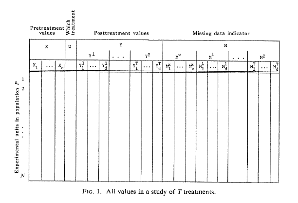

- $y_i(A_1, \dots, A_N) = y_i(A_i)$: outcomes for $i$ depend only on $i$’s own treatment — the “stable unit treatment value assumption” (SUTVA), or “no interference”.
- Unit level causal effects are fixed a priori: compare $y_i(a)$ to $y_i(\tilde{a})$. Effects are defined in an “agnostic”, “non-parametric” way.
- Potential outcomes and covariates are non-random. Treatment is random.

## Examples of causal effects

Suppose $\mathcal{A} = \{0, 1\}$, and define observed outcomes as $y_i \equiv A_i y_i(1) + (1 - A_i) y_i(0)$.

- **Unit level treatment effect:** $\tau_i = y_i(1) - y_i(0)$
- **Average treatment effect (ATE):** $\frac{1}{N} \sum_{i=1}^N \left(y_i(1) - y_i(0)\right)$
- **Average effect of treatment on the treated (ATT):** $\frac{1}{\sum_{i=1}^N A_i} \sum_{i:A_i=1} \left(y_i(1) - y_i(0)\right)$

Many more become available once we add mediators or relax SUTVA, e.g.

- average causal mediation effects
- average global treatment effect $\frac{1}{N}\sum_i \left(y_i(\mathbf{1}) - y_i(\mathbf{0})\right)$ under interference (session 12).

## Manipulability

- Effects are defined by letting only treatments vary, holding units fixed. (“Clear counterfactual comparison.”)
- Thus, causal effects are clearly defined for units that can conceivably receive different treatment values.
  - A test for the above is manipulation:
  - (Holland 1986): “For causal inference, it is critical that each unit be potentially exposable to any one of the causes.”
  - (Angrist and Krueger 1999): “The problem of ambiguous counterfactuals is typically resolved by focusing on hypothetic manipulations in the world as is.”
- What do we mean by race or gender as causes? (Sen and Wasow 2016)
- This test may also entail questions of *power* to change the world (Dimmery and Munger 2025).

## What do we mean by ‘identification’?

- Identification refers generally to sufficiency for drawing a conclusion given the type of data that are available.
- Ambiguity due to lack of identification is distinct from uncertainty due to sampling.

> Studies of identification seek to characterize the conclusions that could be drawn if one could…obtain an unlimited number of observations. Identification problems cannot be solved by gathering more of the same kind of data.

> — (Manski 1995, 4)
- **Identification analysis** shows how to use assumptions on the data generating process to go from observed outcomes to counterfactual/potential outcomes.
- **Identification strategy** is a way to make use of such assumptions to generate causal estimates (Angrist and Krueger 1999).
- This class mostly focuses not on identification, but on what comes before (experimental design) and what comes after (estimation).

## Causal identification with POs

- **Superpopulation setting:** the data are a representative random sample from some notional population, $\mathcal{U}$, countable but large (possibly infinite).
- Consider a random draw, $i$, from $\mathcal{U}$; $E[\cdot]$ is the expected value for such a draw.
  - Capital letters carry this ex ante uncertainty: a covariate vector $X_i$, a treatment assignment $A_i \in \{0,1\}$, and, under SUTVA, potential outcomes $Y_i(1)$ and $Y_i(0)$.
- The unit level effect is $\tau_i = Y_i(1) - Y_i(0)$, so that $E[\tau_i] = \tau$, the average treatment effect.
- For an arbitrary draw, we observe $Y_i = A_i Y_i(1) + (1 - A_i) Y_i(0)$.

Consider the *expected* difference in means:

$$E[Y_i\mid A_i = 1] - E[Y_i\mid A_i = 0] = E[Y_i(\hlred{1})\mid A_i = 1] - E[Y_i(\hlred{0})\mid A_i = 0]$$

Then what does this difference equal?

## Decompositions

Various decompositions are possible. E.g. consider a decomposition wrt the ATT:

$$\begin{align}
E[Y_i\mid A_i = 1] - E[Y_i\mid A_i = 0] &= E[Y_i(1)\mid A_i = 1] - E[Y_i(0)\mid A_i = 0]\\
&= \underbrace{E[Y_i(1)\mid A_i = 1] - \hlblue{E[Y_i(0)\mid A_i = 1]}}_{\text{Average treatment effect on the treated (ATT)}}\\
&+ \underbrace{\hlblue{E[Y_i(0)\mid A_i = 1]} - E[Y_i(0)\mid A_i = 0]}_{\text{Selection bias}}.
\end{align}$$

- Biased for the ATT when $Y_i(0)$’s of treated differ from those of controls.
- *Exercise:* what is the analogous decomposition with respect to the ATC?

## Causal identification under the PO model

**Identifying assumption 1 (random assignment):**

$$A_i \perp (Y_i(1), Y_i(0)) \quad\text{and}\quad 0 < \Pr[A_i = 1] < 1 \qquad (*)$$

Under $(*)$, the selection bias term vanishes,

$$\underbrace{E[Y_i(0)\mid A_i = 1] - E[Y_i(0)\mid A_i = 0]}_{\text{Selection bias}} = 0,$$

and the ATT is the ATE,

$$\underbrace{E[Y_i(1)\mid A_i = 1] - E[Y_i(0)\mid A_i = 1]}_{\text{ATT}} = E[Y_i(1) - Y_i(0)] = \tau.$$

Both hold because conditioning on $A_i$ is uninformative about $(Y_i(1), Y_i(0))$.

So the difference in means identifies the ATE. We now turn to the steps that follow identification — *estimation and inference* — for a randomized experiment on a random sample.

## Population, target, and design

**Population**

- A large population $\mathcal{U}$ of units.
- We consider a treatment, $A_j \in \{0, 1\}$, for which each unit $j \in \mathcal{U}$ has potential outcomes, $(y_j(1), y_j(0))$.
- Unit level causal effect $\tau_j = y_j(1) - y_j(0)$.
- Each unit is also characterized by a continuous covariate, $x_j$.

**Target**

- **Population average treatment effect (PATE):**

$$\tau := \frac{1}{\lvert\mathcal{U}\rvert} \sum_{j \in \mathcal{U}} \left(y_j(1) - y_j(0)\right) = E[Y_i(1) - Y_i(0)],$$

where $E[\cdot]$ is with respect to drawing a unit from $\mathcal{U}$ at random with equal probability.

## Design-based uncertainty

Consider the whole population “inference” problem again:

- A potential outcome is revealed only when the associated treatment is assigned: we observe $y_j = A_j y_j(1) + (1 - A_j) y_j(0)$.
- Therefore, we cannot directly compute our target quantity:
  $$\tau := \frac{1}{\lvert\mathcal{U}\rvert} \sum_{j \in \mathcal{U}} \left(y_j(1) - y_j(0)\right)$$
- The assignment $A_j$ is equivalent to a sampling indicator, sampling potential outcomes.
- The treated group in the population is a *sample* of $y(1)$ values, and the control group is a *sample* of $y(0)$ values.
- So questions of statistical inference do arise for causal quantities even when you observe every unit in the population.
- (Abadie et al. 2020): “design-based uncertainty”

## From population to sample

- Now consider a design that includes both sampling and random assignment (two sources of uncertainty).
- Draw a random sample (e.g., SRSWOR) from $\mathcal{U}$ and call it $\mathcal{S}$. Slots in $\mathcal{S}$ are indexed by $i = 1, \ldots, N$.
- An arbitrary member of $\mathcal{S}$ is characterized by potential outcomes, $(Y_i(1), Y_i(0))$, and a covariate, $X_i$; with unit level effect $\tau_i = Y_i(1) - Y_i(0)$.
- **Sample average treatment effect (SATE):**

$$\tau_{\mathcal{S}} := \frac{1}{N} \sum_{i \in \mathcal{S}} \left(Y_i(1) - Y_i(0)\right) = \frac{1}{N} \sum_{i \in \mathcal{S}} \tau_i$$

- SATE is a random quantity with distribution from the sampling design.
- For any given $\mathcal{S}$, SATE may not equal the PATE:
  - sampling-based uncertainty we need to account for.

## Complete random assignment

- We randomly assign $1 < N_1 < N - 1$ units to treatment $(A_i = 1)$, in which case $N_0 = N - N_1$ are assigned to control. We observe $Y_i = A_i Y_i(1) + (1 - A_i) Y_i(0)$.
- Consider an intuitive **estimator** for the SATE,

$$\hat{\tau} = \frac{1}{N_1} \sum_{i: A_i=1} Y_i - \frac{1}{N_0} \sum_{i: A_i=0} Y_i = \bar{Y}_1 - \bar{Y}_0.$$

- For any given **treatment assignment**, this will not equal SATE exactly: design-based uncertainty. Total uncertainty = sampling-based + design-based.

Let $E_A[\cdot \mid \mathcal{S}]$ mean “expectations over assignments, holding $\mathcal{S}$ fixed.” Complete random assignment is SRSWOR of the sample potential outcomes, so

$$E_A[\hat{\tau}\mid \mathcal{S}] = \frac{1}{N} \sum_{i \in \mathcal{S}} \left(Y_i(1) - Y_i(0)\right) = \tau_{\mathcal{S}}, \qquad E\big[E_A[\hat{\tau}\mid \mathcal{S}]\big] = \tau.$$

$\hat{\tau}$ is unbiased for SATE, and — under random sampling too — for PATE.

## The randomization variance

Complete random assignment is like SRSWOR for potential outcomes, so

$$\text{Var}_A[\hat{\tau} \mid \mathcal{S}] = \text{Var}_A[\bar{Y}_1 \mid \mathcal{S}] + \text{Var}_A[\bar{Y}_0 \mid \mathcal{S}] - 2\text{Cov}_A[\bar{Y}_1, \bar{Y}_0 \mid \mathcal{S}]$$

$$= \frac{s_{Y(1)}^2}{N_1} \left(\frac{N - N_1}{N}\right) + \frac{s_{Y(0)}^2}{N_0} \left(\frac{N - N_0}{N}\right) - 2 \left(-\frac{s_{Y(1),Y(0)}}{N}\right)$$

$$= \frac{s_{Y(1)}^2}{N_1} + \frac{s_{Y(0)}^2}{N_0} - \underbrace{\frac{s_{Y(1)}^2 + s_{Y(0)}^2 - 2s_{Y(1),Y(0)}}{N}}_{\text{numerator} \;=\; \text{Var}_A[\tau_i \mid \mathcal{S}]} \;=\; \frac{s_{Y(1)}^2}{N_1} + \frac{s_{Y(0)}^2}{N_0} - \frac{s_\tau^2}{N}.$$

($s^2_\cdot$ is a sample variance and $s_{\cdot,\cdot}$ a sample covariance.)

## Variance identification

$$\text{Var}_A[\hat{\tau} \mid \mathcal{S}] = \frac{s_{Y(1)}^2}{N_1} + \frac{s_{Y(0)}^2}{N_0} - \frac{s_\tau^2}{N}$$

- The first two terms are identified, the third is not. (Why?)
- $s_\tau^2$ enters with a **minus** sign, so ignoring it overstates the randomization variance.
- $\text{Var}_A[\hat{\tau} \mid \mathcal{S}]$ is therefore largest when $s_\tau^2 = 0$ — when $\tau_i$ is **constant** over $i$ (a linear shift, $Y_i(1) = \tau + Y_i(0)$).
  - Effect *heterogeneity* works in our favour: it pushes the true randomization variance below what we are able to estimate.
- The variance goes to zero in $N_1, N_0$, so the distribution of $\hat{\tau}$ zeroes in on SATE. We say “$\hat{\tau}$ is consistent for SATE in $N_1, N_0$.”

## Back to the population

- Now let’s characterize **total** uncertainty (sampling+design). Recall $E[\hat{\tau}] = \text{PATE}$.
- ANOVA theorem: $\text{Var}[A] = E[\text{Var}[A \mid B]] + \text{Var}[E[A \mid B]]$. (From the CEF decomposition.)

$$\begin{align}
\text{Var}[\hat{\tau}] &= E\big[\text{Var}_A[\hat{\tau}\mid \mathcal{S}]\big] + \text{Var}\big[E_A[\hat{\tau}\mid \mathcal{S}]\big]\\
&= E\left[\frac{s_{Y(1)}^2}{N_1} + \frac{s_{Y(0)}^2}{N_0} - \frac{s_\tau^2}{N}\right] + \text{Var}\left[\frac{1}{N} \sum_{i \in \mathcal{S}} \tau_i\right]\\
&= \frac{\sigma_{Y(1)}^2}{N_1} + \frac{\sigma_{Y(0)}^2}{N_0} \hlred{- \frac{\sigma_\tau^2}{N} + \frac{\sigma_\tau^2}{N}}
\;=\; \frac{\sigma_{Y(1)}^2}{N_1} + \frac{\sigma_{Y(0)}^2}{N_0}.
\end{align}$$

- The unidentified term cancels: the sampling variance of SATE is exactly the piece we could not estimate.
- So $\hat{\tau}$ is also consistent for PATE in $N_1, N_0$.

## Inference for SATE or PATE

Conventional sample variances are unbiased for these population variances, so

$$\hat{V} = \frac{s_{Y(1)}^2}{N_1} + \frac{s_{Y(0)}^2}{N_0}$$

is unbiased for $\text{Var}[\hat{\tau}]$ — different than $\text{Var}_A[\hat{\tau}\mid \mathcal{S}]$.

- $\hat{V}$ is the “Neyman Variance Estimator.” Three interpretations:
  - **Conservative approximation** of the randomization variance, relative to SATE, for arbitrary effects.
  - **Unbiased** for that randomization variance when the effect is constant.
  - **Unbiased** for sampling *plus* randomization variance, relative to PATE, for arbitrary effects.
- Equiv. to the “HC2” heteroskedasticity robust estimator (Samii and Aronow 2012) — R’s `sandwich` or `estimatr`; very close to Eicker-White.
- Also approximated by a nonparametric bootstrap of $N_1$ treatment and $N_0$ control units (Morgan 2017 Prop. 8).

# Simulation Studies

## Simulation Studies

Computational studies of the properties of some method

- Simulate ground truth
- Analyze the data
- Compare to ground truth

Use them to check:

- Your understanding
- Robustness of software
- The performance of statistical methods
- Which method works better
- How to use the method in your work (e.g. sample sizes / power)

## A Useful Guide: (Morris, White, and Crowther 2019)

[figure not shown]

## ADEMP

1. Aims
2. Data-generating mechanisms
3. Estimand
4. Methods
5. Performance measures

⇒ Implementation

## Aims

What are you trying to do with this study method?

It may:

- be the only available method for a specific problem
- perform better than an existing method
- perform slightly less well but be more reliable
- be less reliable but faster
- be more robust under model misspecification

## So what does that mean we care about?

- Whether/when the approach converges?
- Consistency? (large-sample properties)
- Small-sample properties?
- Correct variance formula? (e.g. when derived from theory)
- Robustness to misspecification?
- Comparison with other approaches?

## Data-generating mechanisms

- Set out how the data will be created
- Start with something simple, like $y_i = 1 + x_i + \varepsilon_i$ where $\varepsilon_i \sim N(0,1)$
- This is where a lot of the magic happens as you use what you know about the method to think about what would be good test-cases.
- Think about where the randomization comes from!

## Some options

1. Simulate data from a known model (“parametric” simulation)
2. Resample from a set of data
3. A combination of (1) and (2)
   - Keep covariates fixed, but simulate the outcome
   - Keep everything observed fixed, but simulate the counterfactuals

## Estimand and methods

- What quantity is the analysis trying to estimate?
  - Estimand: the thing we are trying to estimate
  - Estimator: method for estimating an estimand
  - Estimate: number output by applying estimator

Then, the methods:

- Set out how each simulated data set will be analysed to give an estimate of the estimand.
- It’s often good to include a familiar ‘benchmark’ method as a check.

## Performance measures

What is a good result?

Let’s call the chosen estimand $\theta$.

Often, a statistical method outputs an estimate $\hat{\theta}$, its standard error $\widehat{s}(\hat{\theta})$ and a confidence interval $[\hat{\theta}_{low}, \hat{\theta}_{high}]$.

**Properties of $\hat{\theta}$:**

- **Bias**
- **Variance**
- **MSE**
- **Convergence**
- **Compute speed**

**Properties of $\widehat{s}(\hat{\theta})$:**

- **Average magnitude**
- **Bias/MSE relative to theory**

**Properties of CI:**

- **Coverage**
- **Power**
- **Size**

## Which to use?

- Don’t mindlessly report everything!
- Choice of reported measures should relate back to aims.
- Trade-offs between performance measures:
  - e.g. some bias might be OK if MSE and coverage are good.
- In general, need ≥3 performance measures capturing
  - is estimator biased? [Bias]
  - is estimator efficient? [EmpSE; Power]
  - is standard error adequate? [ModSE/EmpSE; Coverage]

## Demo

A standard error means nothing until you say which population it refers to.

# Summary

## What to take away

Design-based causal inference

- Causal effects are contrasts of potential outcomes; the science is fixed, only assignment is random.
- Randomization kills the selection-bias term, so the difference in means identifies the ATE.
- Uncertainty has two sources — sampling and design — and Neyman’s $\hat{V}$ handles both.

Simulation studies

- Simulation is how we interrogate a method when theory runs out: we know the truth by construction.
- Structure the study with ADEMP, and let the aims decide what you report.
- Report at least bias, efficiency, and adequacy of the standard error.

Next week: estimation with covariates — and where machine learning enters.

# References

Abadie, Alberto, Susan Athey, Guido W Imbens, and Jeffrey M Wooldridge. 2020. “Sampling-Based Versus Design-Based Uncertainty in Regression Analysis.” *Econometrica* 88 (1): 265–96.

Angrist, Joshua D, and Alan B Krueger. 1999. “Empirical Strategies in Labor Economics.” In *Handbook of Labor Economics*, 3:1277–1366. Elsevier.

Dimmery, Drew, and Kevin Munger. 2025. “Enough?” *Observational Studies* 11 (1): 17.

Holland, Paul W. 1986. “Statistics and Causal Inference.” *Journal of the American Statistical Association* 81 (396): 945–60.

Inwagen, Peter van, Meghan Sullivan, and Sara Bernstein. 2023. “Metaphysics.” In *The Stanford Encyclopedia of Philosophy*, edited by Edward N. Zalta and Uri Nodelman, Summer 2023. https://plato.stanford.edu/archives/sum2023/entries/metaphysics/; Metaphysics Research Lab, Stanford University.

Manski, Charles F. 1995. *Identification Problems in the Social Sciences*. Harvard University Press.

Morgan, Kari Lock. 2017. “Reallocating and Resampling: A Comparison for Inference.” https://arxiv.org/abs/1708.02102.

Morris, Tim P, Ian R White, and Michael J Crowther. 2019. “Using Simulation Studies to Evaluate Statistical Methods.” *Statistics in Medicine* 38 (11): 2074–2102.

Rubin, Donald B. 1974. “Estimating Causal Effects of Treatments in Randomized and Nonrandomized Studies.” *Journal of Educational Psychology* 66 (5): 688.

———. 1978. “Bayesian Inference for Causal Effects: The Role of Randomization.” *The Annals of Statistics*, 34–58.

Samii, Cyrus, and Peter M Aronow. 2012. “On Equivalencies Between Design-Based and Regression-Based Variance Estimators for Randomized Experiments.” *Statistics & Probability Letters* 82 (2): 365–70.

Sen, Maya, and Omar Wasow. 2016. “Race as a Bundle of Sticks: Designs That Estimate Effects of Seemingly Immutable Characteristics.” *Annual Review of Political Science* 19: 499–522. https://doi.org/10.1146/annurev-polisci-032015-010015.

Splawa-Neyman, Jerzy, D. M. Dabrowska, and T. P. Speed. 1990. “On the Application of Probability Theory to Agricultural Experiments. Essay on Principles. Section 9.” *Statistical Science* 5 (4): 465–72. https://doi.org/10.1214/ss/1177012031.